# HIPOVITAMINOSIS D AND IRON DEFICIENCY IN CHILDREN, A NEW APPROACH TO ITS UNEXPLAINED RELATIONSHIP WITH OSTEOARTICULAR PAIN

María Amelia Muñoz Calonge, Marcos Marvá Ruiz, David Varillas Delgado, José Jiménez Martínez and Manuel Rodríguez Zapata

2023-05-22nd

This document gathers the code we used to the statistical analysis of the data presented in the above referred manuscript.

### Data reading

```r
rm(list = ls())

dfcase0 = read.table(file = "cases_ms.csv", header = T, dec = ".", sep = ";")

dfcontrol0 = read.table(file = "controls_ms.csv", header = T, dec = ".", sep = ";")
```

### Setting baseline values

We first calculate the baseline values for `iron`, `ferritin` and `vitamin D` for both the case and control group. Note that

- Not all the variables have been measured in all the individuals because of occasional failures in the laboratory.
- Not all the individuals in the case group attended the second call and made the second blood test.

Thus:

- We use all the available data to set the baseline value of each variable for each group (case and control). We perform a t test to get a 95% confidence interval for the mean value.
- Once the baseline values are set, we carry in analysing those case individuals that attended twice to the doctor.

#### Case group baseline values

We set the baseline value of each variable by calculating the corresponding confidence interval with the case individuals

```r
t.test(dfcase0$vitaminD, mu = 30, alternative = "two.sided", na.action(dfcase0$vitaminD))
```

```
##
##  One Sample t-test
##
## data:  dfcase0$vitaminD
## t = -2.2349, df = 44, p-value = 0.03055
## alternative hypothesis: true mean is not equal to 30
## 95 percent confidence interval:
##  25.42225 29.76353
## sample estimates:
## mean of x
##  27.59289
```

```r
t.test(dfcase0$iron, mu = 30, alternative = "two.sided",na.action(dfcase0$iron))
```

```
##
##  One Sample t-test
##
## data:  dfcase0$iron
## t = 9.4044, df = 45, p-value = 3.434e-12
## alternative hypothesis: true mean is not equal to 30
## 95 percent confidence interval:
##  67.15965 87.41426
## sample estimates:
## mean of x
##  77.28696
```

```r
t.test(dfcase0$ferritin, mu = 30, alternative = "two.sided",na.action(dfcase0$ferritin))
```

```
##
##  One Sample t-test
##
## data:  dfcase0$ferritin
## t = 3.8991, df = 44, p-value = 0.000326
## alternative hypothesis: true mean is not equal to 30
## 95 percent confidence interval:
##  35.29018 46.60982
## sample estimates:
## mean of x
##     40.95
```

Note that the case group 95% confidence interval for the mean value of `vitamin D` is below the threshold value 30 (deficiency).

#### Control group baseline values

```r
t.test(dfcontrol0$vitaminD, mu = 30, alternative = "two.sided", na.action(dfcontrol0$vitaminD))
```

```
##
##  One Sample t-test
##
## data:  dfcontrol0$vitaminD
## t = 1.0709, df = 35, p-value = 0.2916
## alternative hypothesis: true mean is not equal to 30
## 95 percent confidence interval:
##  28.21100 35.78345
## sample estimates:
## mean of x
##  31.99722
```

```r
t.test(dfcontrol0$iron, mu = 30, alternative = "two.sided",na.action(dfcontrol0$iron))
```

```
##
##  One Sample t-test
##
## data:  dfcontrol0$iron
## t = 11.057, df = 35, p-value = 5.738e-13
## alternative hypothesis: true mean is not equal to 30
## 95 percent confidence interval:
##  73.99461 93.78316
## sample estimates:
## mean of x
##  83.88889
```

```r
t.test(dfcontrol0$ferritin, mu = 30, alternative = "two.sided",na.action(dfcontrol0$ferritin))
```

```
##
##  One Sample t-test
##
## data:  dfcontrol0$ferritin
## t = 3.3764, df = 35, p-value = 0.001811
## alternative hypothesis: true mean is not equal to 30
## 95 percent confidence interval:
##  35.73749 53.04028
## sample estimates:
## mean of x
##  44.38889
```

### Data cleaning

We carry on by removing from the case group those individuals that did not complete the follow up

```r
cases_complete = which(!is.na(dfcase0$iron2) & !is.na(dfcase0$ferritin2) &  !is.na(dfcase0$vitaminD2))
cases = dfcase0[cases_complete , ]
```

```r
dfcontrol0[is.na(dfcontrol0$vitaminD) , ]
```

```
##       sex age weight iron ferritin vitaminD
## 27 female   6   21.0   NA       NA       NA
## 28 female   7   19.0   NA       NA       NA
## 33 female  10   31.0   NA       NA       NA
## 35 female   4   25.5   NA       NA       NA
## 36 female   3   14.0   NA       NA       NA
## 41   male  12   45.0   NA       NA       NA
```

that we, obviously, remove

```r
controls = dfcontrol0[!is.na(dfcontrol0$vitaminD), ]
```

### Data exploration

We first plot scatter plots and box plots for each variable and patient group.

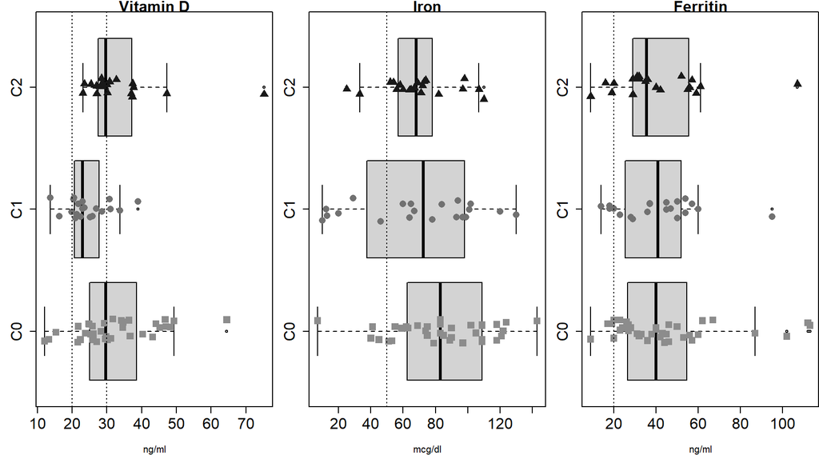

```r
par(mfrow = c(1,3), mar = c(4, 3, 1, 0), cex.axis = 1.5, cex.main = 1.5)

## diagram, VITAMIN D in groups C0, C1 and C2
dfVit = data.frame(vitD = c(cases$vitaminD, cases$vitaminD2, controls$vitaminD),
                   group = c(rep("C1", length(cases$vitaminD)),
                             rep("C2", length(cases$vitaminD2)),
                             rep("C0", length(controls$vitaminD)))
)
boxplot(dfVit$vitD ~ dfVit$group, horizontal = T, main = "Vitamin D",
        xlab = "ng/ml", ylab = "")
stripchart(dfVit$vitD ~ dfVit$group, pch = c(15, 16, 17), add = T,
           col = gray.colors(3, start = 0.1, end = 0.55, gamma = 3.2,
                             rev = TRUE), cex = 1.5,
           method = "jitter", xlim=c(0,max(dfVit$vitD)+1),
           main = "Vitamin D")

# lines indicating vitamin D severe deficiency and vitamin D deficiency, respectively
abline(v = c(20,30), lty = 3)



## diagram, IRON in groups C0, C1 and C2
dfIron = data.frame(Iron = c(cases$iron, cases$iron2, controls$iron),
                    group = c(rep("C1", length(cases$iron)),
                              rep("C2", length(cases$iron2)),
                              rep("C0", length(controls$iron)))
)
boxplot(dfIron$Iron ~ dfIron$group, horizontal = T, main = "Iron",
        xlab = "mcg/dl", ylab = "")
stripchart(dfIron$Iron ~ dfIron$group, pch = c(15, 16, 17), add = T,
           col = gray.colors(3, start = 0.1, end = 0.55, gamma = 3.2,
                             rev = TRUE), cex = 1.5,
           method = "jitter", xlim=c(0,max(dfIron$Iron)+1),
           main = "Iron values")

# line indicating iron deficiency
abline(v = c(50), lty = 3)


## diagram, FERRITIN in groups C0, C1 and C2
dfFerr = data.frame(Ferr = c(cases$ferritin, cases$ferritin2, controls$ferritin),
                    group = c(rep("C1", length(cases$ferritin)),
                              rep("C2", length(cases$ferritin2)),
                              rep("C0", length(controls$ferritin)))
)


boxplot(dfFerr$Ferr ~ dfFerr$group, horizontal = T, main = "Ferritin",
        xlab = "ng/ml", ylab = "")
stripchart(dfFerr$Ferr ~ dfFerr$group, pch = c(15, 16, 17), add = T,
           col = gray.colors(3, start = 0.1, end = 0.55, gamma = 3.2,
                             rev = TRUE), cex = 1.5,
           method = "jitter", xlim=c(0,max(dfIron$Iron)+1),
           main = "Ferritin values")

# line indicating ferritin deficiency
abline(v = c(20), lty = 3)
```

```r
par(mfrow = c(1,1))
```

There are unusually large values for `vitamin D` and `ferritin` in group C2. We next check whether these values belong to the same individual.

```r
which.max(cases$vitaminD2)
```

```
## [1] 8
```

```r
which.max(cases$ferritin2)
```

```
## [1] 3
```

It is not the same individual.

We check also whether these values are strong outliers. That is to say, whether they are beyond three times the IQR from the third quartile.

```r
# VITAMIN D, GROUP C2
max(cases$vitaminD2)
```

```
## [1] 75.2
```

```r
unname(quantile(cases$vitaminD2, probs = 0.75)+3*IQR(cases$vitaminD2))
```

```
## [1] 64.975
```

Yes, it is a strong outlier.

```r
# FERRITIN, GROUP C1
max(cases$ferritin)
```

```
## [1] 95
```

```r
quantile(cases$ferritin, probs = 0.75)+3*IQR(cases$ferritin)
```

```
##    75%
## 123.75
```

No, it is not a strong outlier.

```r
# GROUP C2
max(cases$ferritin2)
```

```
## [1] 107
```

```r
quantile(cases$ferritin2, probs = 0.75)+3*IQR(cases$ferritin2)
```

```
## 75%
## 134
```

No, it is not a strong outlier.

We decide do not remove the strong outlier for Vitamin D in group C2 even if it may affect the mean value due to the small sample size. When necessary, we will check results considering and not considering the strong outlier in order to assess its potential impact:

```r
cases_VitD = cases[ #cases$vitaminD2 != max(cases$vitaminD2)
                    , c("vitaminD", "vitaminD2", "weight", "age")]
```

### Dealing with potential confounders: age and weight

Note that `age` ranges from 2 to 13 years

```r
range(c(cases$age, controls$age))
```

```
## [1]  2 13
```

and `weight` from 10 to 69 kilograms

```r
range(c(cases$weight, controls$weight), na.rm = T)
```

```
## [1] 10 69
```

To prevent confounding variables we analysed the possible association of `vitamin D`, `iron` and `ferritin` to the variables `age` or `weight` by testing H0: *“the slope of the regression line = 0 for each group and variable”*. Let us recall that if the linear assumptions are met (see below),
$$\Xi =
\dfrac{b_1-\beta_1}{\sqrt{\dfrac{MEC}{(n-2)s^2(x)}}} \sim
t_{n-2}$$
where $\beta_1$ is the slope of the linear model $y = \beta_0+\beta_1 x +\varepsilon$ and $b_1$ is its estimate, and $n$ is the sample size.

The following function calculates the value of $\Xi$ under the hypothesis $\beta_1=0$

```r
slopeRtest = function(x, y){
  # remove NAs
  not.na <- (!is.na(x))*(!is.na(y))
  x = x[which(not.na == 1)]
  y = y[which(not.na == 1)]

  # calculate regression line
  lmXY = lm(y ~ x)

  # calculate the statistic
  xi = unname(lmXY$coefficients[2])/( sum((lmXY$fitted.values - y)^2)/((length(x)-2)*var(x)))

  # calculate p-value
  min(2*pt(xi, df = length(x)-2),
      2*pt(xi, df = length(x)-2, lower.tail = F)
      )
}
```

We next display the scatterplot along with the regression line, calculate the 95% confidence interval for $\beta_1$ (we use the `smatr` package ) and test $H_0:\,\it{\beta_1=0}$ (with the above defined function) for age, weight versus `vitamin D`, `iron` and `ferritin` for each group C0, C1 and C2.

In what follows, `lm_XXX_y_z` refers to the linear model of variables `XXX` over `y` in group `Cz`.

##### Vitamin D

**Age**

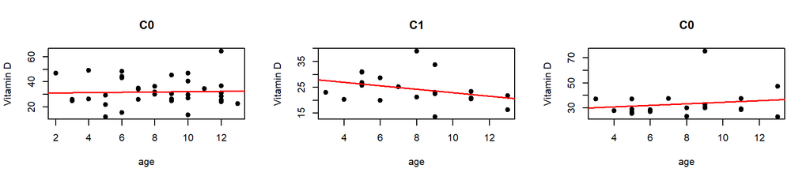

```r
lm_VitD_a_0 = lm(controls$vitaminD ~ controls$age)
lm_VitD_a_1 = lm(cases_VitD$vitaminD ~ cases_VitD$age)
lm_VitD_a_2 = lm(cases_VitD$vitaminD2 ~ cases_VitD$age)

par(mfrow = c(1,3))
plot(controls$age, controls$vitaminD, pch = 19,
     xlab = "age", ylab = "Vitamin D", main = "C0")
abline(lm_VitD_a_0, col = "red", lwd = 1.5)

plot(cases_VitD$age, cases_VitD$vitaminD, pch = 19,
     xlab = "age", ylab = "Vitamin D", main = "C1")
abline(lm_VitD_a_1, col = "red", lwd = 1.5)

plot(cases_VitD$age, cases_VitD$vitaminD2, pch = 19,
     xlab = "age", ylab = "Vitamin D", main = "C0")
abline(lm_VitD_a_2, col = "red", lwd = 1.5)
```

```r
par(mfrow = c(1,1))
```

```r
library(smatr)
confint(lm_VitD_a_0)[2, ]
```

```
##     2.5 %    97.5 %
## -1.152041  1.398528
```

```r
slopeRtest(controls$age, controls$vitaminD)
```

```
## [1] 0.9929177
```

```r
confint(lm_VitD_a_1)[2, ]
```

```
##      2.5 %     97.5 %
## -1.6130222  0.2763065
```

```r
slopeRtest(cases_VitD$age, cases_VitD$vitaminD)
```

```
## [1] 0.8638164
```

```r
confint(lm_VitD_a_2)[2, ]
```

```
##     2.5 %    97.5 %
## -1.256837  2.522403
```

```r
slopeRtest(cases_VitD$age, cases_VitD$vitaminD2)
```

```
## [1] 0.9676143
```

**Weight**

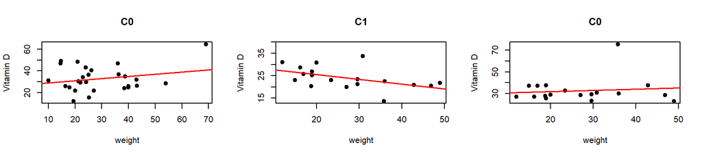

```r
lm_VitD_w_0 = lm(controls$vitaminD ~ controls$weight)
lm_VitD_w_1 = lm(cases_VitD$vitaminD ~ cases_VitD$weight)
lm_VitD_w_2 = lm(cases_VitD$vitaminD2 ~ cases_VitD$weight)

par(mfrow = c(1,3))
plot(controls$weight, controls$vitaminD, pch = 19,
     xlab = "weight", ylab = "Vitamin D", main = "C0")
abline(lm_VitD_w_0, col = "red", lwd = 1.5)

plot(cases_VitD$weight, cases_VitD$vitaminD, pch = 19,
     xlab = "weight", ylab = "Vitamin D", main = "C1")
abline(lm_VitD_w_1, col = "red", lwd = 1.5)

plot(cases_VitD$weight, cases_VitD$vitaminD2, pch = 19,
     xlab = "weight", ylab = "Vitamin D", main = "C0")
abline(lm_VitD_w_2, col = "red", lwd = 1.5)
```

```r
par(mfrow = c(1,1))
```

```r
library(smatr)
confint(lm_VitD_w_0)[2, ]
```

```
##      2.5 %     97.5 %
## -0.1457841  0.5464381
```

```r
slopeRtest(controls$weight, controls$vitaminD)
```

```
## [1] 0.7872331
```

```r
confint(lm_VitD_w_1)[2, ]
```

```
##       2.5 %      97.5 %
## -0.40942742 -0.01057173
```

```r
slopeRtest(cases_VitD$weight, cases_VitD$vitaminD)
```

```
## [1] 0.1818366
```

```r
confint(lm_VitD_w_2)[2, ]
```

```
##      2.5 %     97.5 %
## -0.4356917  0.6500290
```

```r
slopeRtest(cases_VitD$weight, cases_VitD$vitaminD2)
```

```
## [1] 0.9246082
```

##### `iron`

**`age``**

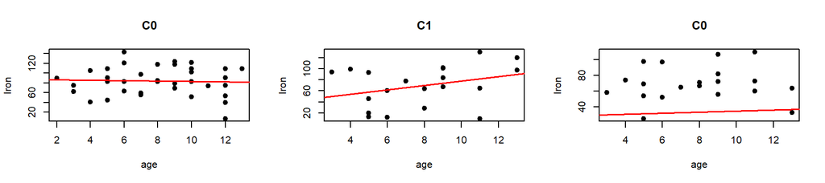

```r
lm_iron_a_0 = lm(controls$iron ~ controls$age)
lm_iron_a_1 = lm(cases$iron ~ cases$age)
lm_iron_a_2 = lm(cases$iron2 ~ cases$age)

par(mfrow = c(1,3))
plot(controls$age, controls$iron, pch = 19,
     xlab = "age", ylab = "Iron", main = "C0")
abline(lm_iron_a_0, col = "red", lwd = 1.5)

plot(cases$age, cases$iron, pch = 19,
     xlab = "age", ylab = "Iron", main = "C1")
abline(lm_iron_a_1, col = "red", lwd = 1.5)

plot(cases$age, cases$iron2, pch = 19,
     xlab = "age", ylab = "Iron", main = "C0")
abline(lm_VitD_a_2, col = "red", lwd = 1.5)
```

```r
par(mfrow = c(1,1))
```

```r
library(smatr)
confint(lm_iron_a_0)[2, ]
```

```
##     2.5 %    97.5 %
## -3.771708  2.890219
```

```r
slopeRtest(controls$age, controls$iron)
```

```
## [1] 0.9962874
```

```r
confint(lm_iron_a_1)[2, ]
```

```
##     2.5 %    97.5 %
## -1.939855  9.832139
```

```r
slopeRtest(cases$age, cases$iron)
```

```
## [1] 0.9791811
```

```r
confint(lm_iron_a_2)[2, ]
```

```
##     2.5 %    97.5 %
## -3.351100  3.976138
```

```r
slopeRtest(cases$age, cases$iron2)
```

```
## [1] 0.9957437
```

**`weight`**

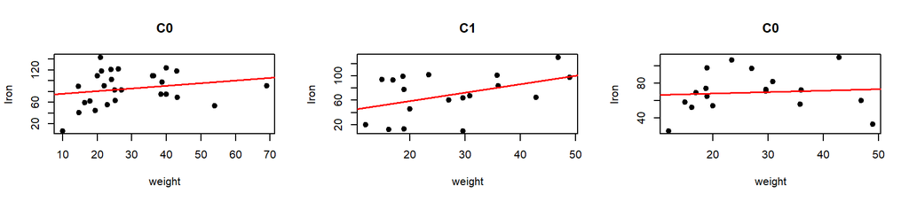

```r
lm_iron_w_0 = lm(controls$iron ~ controls$weight)
lm_iron_w_1 = lm(cases$iron ~ cases$weight)
lm_iron_w_2 = lm(cases$iron2 ~ cases$weight)

par(mfrow = c(1,3))
plot(controls$weight, controls$iron, pch = 19,
     xlab = "weight", ylab = "Iron", main = "C0")
abline(lm_iron_w_0, col = "red", lwd = 1.5)

plot(cases$weight, cases$iron, pch = 19,
     xlab = "weight", ylab = "Iron", main = "C1")
abline(lm_iron_w_1, col = "red", lwd = 1.5)

plot(cases$weight, cases$iron2, pch = 19,
     xlab = "weight", ylab = "Iron", main = "C0")
abline(lm_iron_w_2, col = "red", lwd = 1.5)
```

```r
par(mfrow = c(1,1))
```

```r
library(smatr)
confint(lm_iron_w_0)[2, ]
```

```
##      2.5 %     97.5 %
## -0.4584356  1.4286195
```

```r
slopeRtest(controls$weight, controls$iron)
```

```
## [1] 0.929873
```

```r
confint(lm_iron_w_1)[2, ]
```

```
##      2.5 %     97.5 %
## -0.1376548  2.9108362
```

```r
slopeRtest(cases$weight, cases$iron)
```

```
## [1] 0.8766125
```

```r
confint(lm_iron_w_2)[2, ]
```

```
##      2.5 %     97.5 %
## -0.9187783  1.2538628
```

```r
slopeRtest(cases$weight, cases$iron2)
```

```
## [1] 0.9705258
```

##### `ferritin`

**`age`**

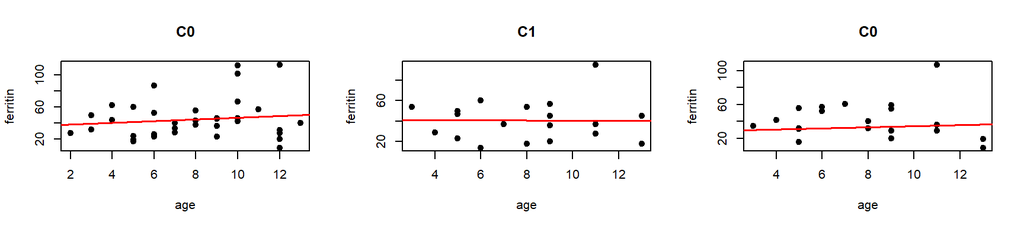

```r
lm_ferritin_a_0 = lm(controls$ferritin ~ controls$age)
lm_ferritin_a_1 = lm(cases$ferritin ~ cases$age)
lm_ferritin_a_2 = lm(cases$ferritin2 ~ cases$age)

par(mfrow = c(1,3))
plot(controls$age, controls$ferritin, pch = 19,
     xlab = "age", ylab = "ferritin", main = "C0")
abline(lm_ferritin_a_0, col = "red", lwd = 1.5)

plot(cases$age, cases$ferritin, pch = 19,
     xlab = "age", ylab = "ferritin", main = "C1")
abline(lm_ferritin_a_1, col = "red", lwd = 1.5)

plot(cases$age, cases$ferritin2, pch = 19,
     xlab = "age", ylab = "ferritin", main = "C0")
abline(lm_VitD_a_2, col = "red", lwd = 1.5)
```

```r
par(mfrow = c(1,1))
```

```r
library(smatr)
confint(lm_ferritin_a_0)[2, ]
```

```
##    2.5 %   97.5 %
## -1.82639  3.95739
```

```r
slopeRtest(controls$age, controls$ferritin)
```

```
## [1] 0.988093
```

```r
confint(lm_ferritin_a_1)[2, ]
```

```
##     2.5 %    97.5 %
## -3.248184  3.182738
```

```r
slopeRtest(cases$age, cases$ferritin)
```

```
## [1] 0.9994214
```

```r
confint(lm_ferritin_a_2)[2, ]
```

```
##     2.5 %    97.5 %
## -4.157423  3.131304
```

```r
slopeRtest(cases$age, cases$ferritin2)
```

```
## [1] 0.9929385
```

**`weight`**

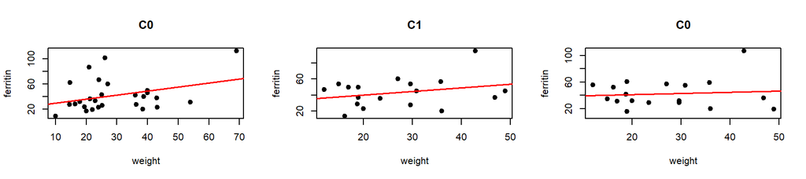

```r
lm_ferritin_w_0 = lm(controls$ferritin ~ controls$weight)
lm_ferritin_w_1 = lm(cases$ferritin ~ cases$weight)
lm_ferritin_w_2 = lm(cases$ferritin2 ~ cases$weight)

par(mfrow = c(1,3))
plot(controls$weight, controls$ferritin, pch = 19,
     xlab = "weight", ylab = "ferritin", main = "C0")
abline(lm_ferritin_w_0, col = "red", lwd = 1.5)

plot(cases$weight, cases$ferritin, pch = 19,
     xlab = "weight", ylab = "ferritin", main = "C1")
abline(lm_ferritin_w_1, col = "red", lwd = 1.5)

plot(cases$weight, cases$ferritin2, pch = 19,
     xlab = "weight", ylab = "ferritin", main = "C0")
abline(lm_ferritin_w_2, col = "red", lwd = 1.5)
```

```r
par(mfrow = c(1,1))
```

```r
library(smatr)
confint(lm_ferritin_w_0)[2, ]
```

```
##       2.5 %      97.5 %
## -0.09895068  1.38565230
```

```r
slopeRtest(controls$weight, controls$ferritin)
```

```
## [1] 0.8504699
```

```r
confint(lm_ferritin_w_1)[2, ]
```

```
##      2.5 %     97.5 %
## -0.3839609  1.2977935
```

```r
slopeRtest(cases$weight, cases$ferritin)
```

```
## [1] 0.8665017
```

```r
confint(lm_ferritin_w_2)[2, ]
```

```
##      2.5 %     97.5 %
## -0.8340418  1.1999014
```

```r
slopeRtest(cases$weight, cases$ferritin2)
```

```
## [1] 0.9632852
```

#### Linear model assumptions

##### Vitamin D

```r
library(gvlma)
gvlma(lm_VitD_a_0)
```

```
##
## Call:
## lm(formula = controls$vitaminD ~ controls$age)
##
## Coefficients:
##  (Intercept)  controls$age
##      31.0147        0.1232
##
##
## ASSESSMENT OF THE LINEAR MODEL ASSUMPTIONS
## USING THE GLOBAL TEST ON 4 DEGREES-OF-FREEDOM:
## Level of Significance =  0.05
##
## Call:
##  gvlma(x = lm_VitD_a_0)
##
##                       Value  p-value                   Decision
## Global Stat        10.59256 0.031546 Assumptions NOT satisfied!
## Skewness            2.62248 0.105360    Assumptions acceptable.
## Kurtosis            0.21674 0.641537    Assumptions acceptable.
## Link Function       0.07886 0.778843    Assumptions acceptable.
## Heteroscedasticity  7.67448 0.005601 Assumptions NOT satisfied!
```

```r
gvlma(lm_VitD_a_1)
```

```
##
## Call:
## lm(formula = cases_VitD$vitaminD ~ cases_VitD$age)
##
## Coefficients:
##    (Intercept)  cases_VitD$age
##        29.6416         -0.6684
##
##
## ASSESSMENT OF THE LINEAR MODEL ASSUMPTIONS
## USING THE GLOBAL TEST ON 4 DEGREES-OF-FREEDOM:
## Level of Significance =  0.05
##
## Call:
##  gvlma(x = lm_VitD_a_1)
##
##                     Value p-value                Decision
## Global Stat        6.4162  0.1701 Assumptions acceptable.
## Skewness           2.2568  0.1330 Assumptions acceptable.
## Kurtosis           0.6848  0.4079 Assumptions acceptable.
## Link Function      1.7018  0.1921 Assumptions acceptable.
## Heteroscedasticity 1.7728  0.1830 Assumptions acceptable.
```

```r
gvlma(lm_VitD_a_2)
```

```
##
## Call:
## lm(formula = cases_VitD$vitaminD2 ~ cases_VitD$age)
##
## Coefficients:
##    (Intercept)  cases_VitD$age
##        28.2627          0.6328
##
##
## ASSESSMENT OF THE LINEAR MODEL ASSUMPTIONS
## USING THE GLOBAL TEST ON 4 DEGREES-OF-FREEDOM:
## Level of Significance =  0.05
##
## Call:
##  gvlma(x = lm_VitD_a_2)
##
##                       Value   p-value                   Decision
## Global Stat        63.65273 4.945e-13 Assumptions NOT satisfied!
## Skewness           21.31276 3.901e-06 Assumptions NOT satisfied!
## Kurtosis           41.51452 1.170e-10 Assumptions NOT satisfied!
## Link Function       0.05424 8.158e-01    Assumptions acceptable.
## Heteroscedasticity  0.77121 3.798e-01    Assumptions acceptable.
```

```r
gvlma(lm_VitD_w_0)
```

```
##
## Call:
## lm(formula = controls$vitaminD ~ controls$weight)
##
## Coefficients:
##     (Intercept)  controls$weight
##         26.8741           0.2003
##
##
## ASSESSMENT OF THE LINEAR MODEL ASSUMPTIONS
## USING THE GLOBAL TEST ON 4 DEGREES-OF-FREEDOM:
## Level of Significance =  0.05
##
## Call:
##  gvlma(x = lm_VitD_w_0)
##
##                      Value  p-value                   Decision
## Global Stat        13.5829 0.008753 Assumptions NOT satisfied!
## Skewness            1.0091 0.315122    Assumptions acceptable.
## Kurtosis            0.4715 0.492277    Assumptions acceptable.
## Link Function       5.7650 0.016349 Assumptions NOT satisfied!
## Heteroscedasticity  6.3373 0.011823 Assumptions NOT satisfied!
```

```r
gvlma(lm_VitD_w_1)
```

```
##
## Call:
## lm(formula = cases_VitD$vitaminD ~ cases_VitD$weight)
##
## Coefficients:
##       (Intercept)  cases_VitD$weight
##             29.72              -0.21
##
##
## ASSESSMENT OF THE LINEAR MODEL ASSUMPTIONS
## USING THE GLOBAL TEST ON 4 DEGREES-OF-FREEDOM:
## Level of Significance =  0.05
##
## Call:
##  gvlma(x = lm_VitD_w_1)
##
##                       Value p-value                Decision
## Global Stat        1.437117  0.8377 Assumptions acceptable.
## Skewness           0.418069  0.5179 Assumptions acceptable.
## Kurtosis           0.469930  0.4930 Assumptions acceptable.
## Link Function      0.541050  0.4620 Assumptions acceptable.
## Heteroscedasticity 0.008068  0.9284 Assumptions acceptable.
```

```r
gvlma(lm_VitD_w_2)
```

```
##
## Call:
## lm(formula = cases_VitD$vitaminD2 ~ cases_VitD$weight)
##
## Coefficients:
##       (Intercept)  cases_VitD$weight
##           29.7185             0.1072
##
##
## ASSESSMENT OF THE LINEAR MODEL ASSUMPTIONS
## USING THE GLOBAL TEST ON 4 DEGREES-OF-FREEDOM:
## Level of Significance =  0.05
##
## Call:
##  gvlma(x = lm_VitD_w_2)
##
##                      Value   p-value                   Decision
## Global Stat        70.6293 1.676e-14 Assumptions NOT satisfied!
## Skewness           22.6612 1.932e-06 Assumptions NOT satisfied!
## Kurtosis           45.1747 1.802e-11 Assumptions NOT satisfied!
## Link Function       0.8758 3.493e-01    Assumptions acceptable.
## Heteroscedasticity  1.9176 1.661e-01    Assumptions acceptable.
```

##### `iron`

```r
library(gvlma)
gvlma(lm_iron_a_0)
```

```
##
## Call:
## lm(formula = controls$iron ~ controls$age)
##
## Coefficients:
##  (Intercept)  controls$age
##      87.4026       -0.4407
##
##
## ASSESSMENT OF THE LINEAR MODEL ASSUMPTIONS
## USING THE GLOBAL TEST ON 4 DEGREES-OF-FREEDOM:
## Level of Significance =  0.05
##
## Call:
##  gvlma(x = lm_iron_a_0)
##
##                      Value p-value                Decision
## Global Stat        2.92290  0.5708 Assumptions acceptable.
## Skewness           0.47097  0.4925 Assumptions acceptable.
## Kurtosis           0.08889  0.7656 Assumptions acceptable.
## Link Function      1.95058  0.1625 Assumptions acceptable.
## Heteroscedasticity 0.41247  0.5207 Assumptions acceptable.
```

```r
gvlma(lm_iron_a_1)
```

```
##
## Call:
## lm(formula = cases$iron ~ cases$age)
##
## Coefficients:
## (Intercept)    cases$age
##      38.233        3.946
##
##
## ASSESSMENT OF THE LINEAR MODEL ASSUMPTIONS
## USING THE GLOBAL TEST ON 4 DEGREES-OF-FREEDOM:
## Level of Significance =  0.05
##
## Call:
##  gvlma(x = lm_iron_a_1)
##
##                     Value p-value                Decision
## Global Stat        3.4942  0.4788 Assumptions acceptable.
## Skewness           0.4749  0.4908 Assumptions acceptable.
## Kurtosis           0.6628  0.4156 Assumptions acceptable.
## Link Function      1.9225  0.1656 Assumptions acceptable.
## Heteroscedasticity 0.4340  0.5100 Assumptions acceptable.
```

```r
gvlma(lm_iron_a_2)
```

```
##
## Call:
## lm(formula = cases$iron2 ~ cases$age)
##
## Coefficients:
## (Intercept)    cases$age
##     66.8967       0.3125
##
##
## ASSESSMENT OF THE LINEAR MODEL ASSUMPTIONS
## USING THE GLOBAL TEST ON 4 DEGREES-OF-FREEDOM:
## Level of Significance =  0.05
##
## Call:
##  gvlma(x = lm_iron_a_2)
##
##                      Value p-value                Decision
## Global Stat        2.63853  0.6200 Assumptions acceptable.
## Skewness           0.01995  0.8877 Assumptions acceptable.
## Kurtosis           0.03176  0.8586 Assumptions acceptable.
## Link Function      2.21499  0.1367 Assumptions acceptable.
## Heteroscedasticity 0.37183  0.5420 Assumptions acceptable.
```

```r
gvlma(lm_iron_w_0)
```

```
##
## Call:
## lm(formula = controls$iron ~ controls$weight)
##
## Coefficients:
##     (Intercept)  controls$weight
##         71.3866           0.4851
##
##
## ASSESSMENT OF THE LINEAR MODEL ASSUMPTIONS
## USING THE GLOBAL TEST ON 4 DEGREES-OF-FREEDOM:
## Level of Significance =  0.05
##
## Call:
##  gvlma(x = lm_iron_w_0)
##
##                      Value p-value                   Decision
## Global Stat        4.82133 0.30613    Assumptions acceptable.
## Skewness           0.07830 0.77961    Assumptions acceptable.
## Kurtosis           0.32580 0.56814    Assumptions acceptable.
## Link Function      4.35529 0.03689 Assumptions NOT satisfied!
## Heteroscedasticity 0.06194 0.80345    Assumptions acceptable.
```

```r
gvlma(lm_iron_w_1)
```

```
##
## Call:
## lm(formula = cases$iron ~ cases$weight)
##
## Coefficients:
##  (Intercept)  cases$weight
##       31.053         1.387
##
##
## ASSESSMENT OF THE LINEAR MODEL ASSUMPTIONS
## USING THE GLOBAL TEST ON 4 DEGREES-OF-FREEDOM:
## Level of Significance =  0.05
##
## Call:
##  gvlma(x = lm_iron_w_1)
##
##                     Value p-value                Decision
## Global Stat        1.3862  0.8466 Assumptions acceptable.
## Skewness           0.1385  0.7098 Assumptions acceptable.
## Kurtosis           0.7629  0.3824 Assumptions acceptable.
## Link Function      0.2525  0.6153 Assumptions acceptable.
## Heteroscedasticity 0.2324  0.6298 Assumptions acceptable.
```

```r
gvlma(lm_iron_w_2)
```

```
##
## Call:
## lm(formula = cases$iron2 ~ cases$weight)
##
## Coefficients:
##  (Intercept)  cases$weight
##      65.2383        0.1675
##
##
## ASSESSMENT OF THE LINEAR MODEL ASSUMPTIONS
## USING THE GLOBAL TEST ON 4 DEGREES-OF-FREEDOM:
## Level of Significance =  0.05
##
## Call:
##  gvlma(x = lm_iron_w_2)
##
##                        Value p-value                   Decision
## Global Stat        7.798e+00 0.09928    Assumptions acceptable.
## Skewness           4.865e-06 0.99824    Assumptions acceptable.
## Kurtosis           1.704e-01 0.67976    Assumptions acceptable.
## Link Function      6.599e+00 0.01020 Assumptions NOT satisfied!
## Heteroscedasticity 1.028e+00 0.31070    Assumptions acceptable.
```

##### `ferritin`

```r
library(gvlma)
gvlma(lm_ferritin_a_0)
```

```
##
## Call:
## lm(formula = controls$ferritin ~ controls$age)
##
## Coefficients:
##  (Intercept)  controls$age
##       35.894         1.065
##
##
## ASSESSMENT OF THE LINEAR MODEL ASSUMPTIONS
## USING THE GLOBAL TEST ON 4 DEGREES-OF-FREEDOM:
## Level of Significance =  0.05
##
## Call:
##  gvlma(x = lm_ferritin_a_0)
##
##                      Value  p-value                   Decision
## Global Stat        9.90665 0.042030 Assumptions NOT satisfied!
## Skewness           7.99419 0.004693 Assumptions NOT satisfied!
## Kurtosis           1.21361 0.270619    Assumptions acceptable.
## Link Function      0.63611 0.425124    Assumptions acceptable.
## Heteroscedasticity 0.06275 0.802208    Assumptions acceptable.
```

```r
gvlma(lm_ferritin_a_1)
```

```
##
## Call:
## lm(formula = cases$ferritin ~ cases$age)
##
## Coefficients:
## (Intercept)    cases$age
##    41.10687     -0.03272
##
##
## ASSESSMENT OF THE LINEAR MODEL ASSUMPTIONS
## USING THE GLOBAL TEST ON 4 DEGREES-OF-FREEDOM:
## Level of Significance =  0.05
##
## Call:
##  gvlma(x = lm_ferritin_a_1)
##
##                       Value p-value                   Decision
## Global Stat        7.610063 0.10695    Assumptions acceptable.
## Skewness           2.560822 0.10954    Assumptions acceptable.
## Kurtosis           1.186840 0.27597    Assumptions acceptable.
## Link Function      0.001874 0.96547    Assumptions acceptable.
## Heteroscedasticity 3.860527 0.04943 Assumptions NOT satisfied!
```

```r
gvlma(lm_ferritin_a_2)
```

```
##
## Call:
## lm(formula = cases$ferritin2 ~ cases$age)
##
## Coefficients:
## (Intercept)    cases$age
##     44.8775      -0.5131
##
##
## ASSESSMENT OF THE LINEAR MODEL ASSUMPTIONS
## USING THE GLOBAL TEST ON 4 DEGREES-OF-FREEDOM:
## Level of Significance =  0.05
##
## Call:
##  gvlma(x = lm_ferritin_a_2)
##
##                     Value   p-value                   Decision
## Global Stat        19.783 0.0005511 Assumptions NOT satisfied!
## Skewness            6.666 0.0098285 Assumptions NOT satisfied!
## Kurtosis            5.960 0.0146336 Assumptions NOT satisfied!
## Link Function       2.126 0.1448390    Assumptions acceptable.
## Heteroscedasticity  5.032 0.0248886 Assumptions NOT satisfied!
```

```r
gvlma(lm_ferritin_w_0)
```

```
##
## Call:
## lm(formula = controls$ferritin ~ controls$weight)
##
## Coefficients:
##     (Intercept)  controls$weight
##         22.8260           0.6434
##
##
## ASSESSMENT OF THE LINEAR MODEL ASSUMPTIONS
## USING THE GLOBAL TEST ON 4 DEGREES-OF-FREEDOM:
## Level of Significance =  0.05
##
## Call:
##  gvlma(x = lm_ferritin_w_0)
##
##                        Value p-value                   Decision
## Global Stat        8.5498575 0.07339    Assumptions acceptable.
## Skewness           6.3113250 0.01200 Assumptions NOT satisfied!
## Kurtosis           0.2902431 0.59006    Assumptions acceptable.
## Link Function      1.9476168 0.16284    Assumptions acceptable.
## Heteroscedasticity 0.0006726 0.97931    Assumptions acceptable.
```

```r
gvlma(lm_ferritin_w_1)
```

```
##
## Call:
## lm(formula = cases$ferritin ~ cases$weight)
##
## Coefficients:
##  (Intercept)  cases$weight
##      31.0090        0.4569
##
##
## ASSESSMENT OF THE LINEAR MODEL ASSUMPTIONS
## USING THE GLOBAL TEST ON 4 DEGREES-OF-FREEDOM:
## Level of Significance =  0.05
##
## Call:
##  gvlma(x = lm_ferritin_w_1)
##
##                      Value p-value                Decision
## Global Stat        2.71031  0.6074 Assumptions acceptable.
## Skewness           0.90405  0.3417 Assumptions acceptable.
## Kurtosis           0.03972  0.8420 Assumptions acceptable.
## Link Function      0.02768  0.8679 Assumptions acceptable.
## Heteroscedasticity 1.73886  0.1873 Assumptions acceptable.
```

```r
gvlma(lm_ferritin_w_2)
```

```
##
## Call:
## lm(formula = cases$ferritin2 ~ cases$weight)
##
## Coefficients:
##  (Intercept)  cases$weight
##      37.7103        0.1829
##
##
## ASSESSMENT OF THE LINEAR MODEL ASSUMPTIONS
## USING THE GLOBAL TEST ON 4 DEGREES-OF-FREEDOM:
## Level of Significance =  0.05
##
## Call:
##  gvlma(x = lm_ferritin_w_2)
##
##                        Value p-value                   Decision
## Global Stat        10.737611 0.02968 Assumptions NOT satisfied!
## Skewness            4.027955 0.04475 Assumptions NOT satisfied!
## Kurtosis            1.948042 0.16280    Assumptions acceptable.
## Link Function       0.002763 0.95808    Assumptions acceptable.
## Heteroscedasticity  4.758850 0.02915 Assumptions NOT satisfied!
```

#### Normality of the variables

Cases (groups C1 and C2) are quite a little (19 or 20 individuals) so that normality must be checked to decide whether to apply a parametric test (`t.test`) or a non-parametric test (`wilcox_test` from the `coin` R package).

```r
# VITAMIN D
# C0
shapiro.test(controls$vitaminD)
```

```
##
##  Shapiro-Wilk normality test
##
## data:  controls$vitaminD
## W = 0.9533, p-value = 0.1328
```

```r
# C1
shapiro.test(cases_VitD$vitaminD)
```

```
##
##  Shapiro-Wilk normality test
##
## data:  cases_VitD$vitaminD
## W = 0.95652, p-value = 0.4768
```

```r
# C2
shapiro.test(cases_VitD$vitaminD2)
```

```
##
##  Shapiro-Wilk normality test
##
## data:  cases_VitD$vitaminD2
## W = 0.6798, p-value = 2.233e-05
```

Normality is reached for groups C0 and C1, but not for group C2. Let us recall the existence of a strong outlier

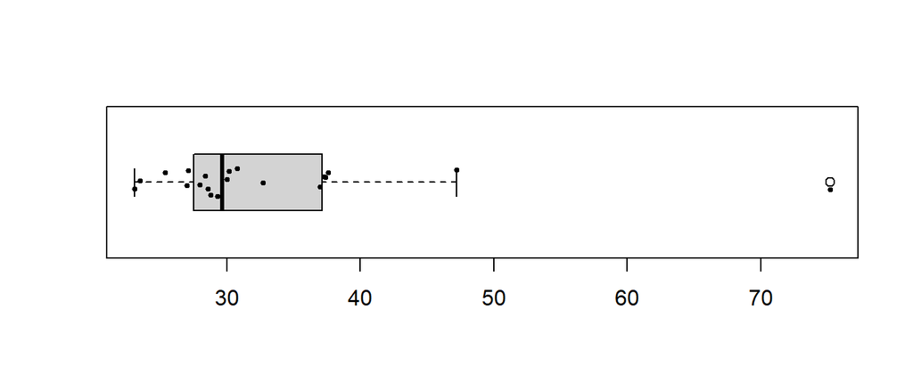

```r
boxplot(cases_VitD$vitaminD2, horizontal = T)
stripchart(cases_VitD$vitaminD2, method = "jitter", cex = .5, pch = 19, add = T)
```

We test normality when removing the strong outlier with the Shapiro test

```r
shapiro.test(cases_VitD$vitaminD2[cases_VitD$vitaminD2!= max(cases_VitD$vitaminD2)])
```

```
##
##  Shapiro-Wilk normality test
##
## data:  cases_VitD$vitaminD2[cases_VitD$vitaminD2 != max(cases_VitD$vitaminD2)]
## W = 0.89694, p-value = 0.04284
```

and also try with the Lilliefors (Kolmogorov-Smirnov) normality test qhen Shapiro’s test is significant

```r
library(nortest)
lillie.test(cases_VitD$vitaminD2[cases_VitD$vitaminD2!= max(cases_VitD$vitaminD2)])
```

```
##
##  Lilliefors (Kolmogorov-Smirnov) normality test
##
## data:  cases_VitD$vitaminD2[cases_VitD$vitaminD2 != max(cases_VitD$vitaminD2)]
## D = 0.19902, p-value = 0.04608
```

Both tests are either significant and yield p-values cole to the threshold value 0.05.

We carry on by assuming that normality is not reached in this case.

```r
##############################
# IRON
# C0
shapiro.test(controls$iron)
```

```
##
##  Shapiro-Wilk normality test
##
## data:  controls$iron
## W = 0.98192, p-value = 0.8083
```

```r
# C1
shapiro.test(cases$iron)
```

```
##
##  Shapiro-Wilk normality test
##
## data:  cases$iron
## W = 0.93403, p-value = 0.1845
```

```r
# C2
shapiro.test(cases$iron2)
```

```
##
##  Shapiro-Wilk normality test
##
## data:  cases$iron2
## W = 0.95636, p-value = 0.474
```

```r
##############################
# FERRITIN
# C0
shapiro.test(controls$ferritin)
```

```
##
##  Shapiro-Wilk normality test
##
## data:  controls$ferritin
## W = 0.86726, p-value = 0.0004877
```

```r
lillie.test(controls$ferritin)
```

```
##
##  Lilliefors (Kolmogorov-Smirnov) normality test
##
## data:  controls$ferritin
## D = 0.16932, p-value = 0.01056
```

```r
# C1
shapiro.test(cases$ferritin)
```

```
##
##  Shapiro-Wilk normality test
##
## data:  cases$ferritin
## W = 0.92144, p-value = 0.1056
```

```r
# C2
shapiro.test(cases$ferritin2)
```

```
##
##  Shapiro-Wilk normality test
##
## data:  cases$ferritin2
## W = 0.89409, p-value = 0.032
```

```r
shapiro.test(cases$ferritin2[cases$ferritin2 != max(cases$ferritin2)])
```

```
##
##  Shapiro-Wilk normality test
##
## data:  cases$ferritin2[cases$ferritin2 != max(cases$ferritin2)]
## W = 0.94368, p-value = 0.3068
```

```r
lillie.test(cases$ferritin2)
```

```
##
##  Lilliefors (Kolmogorov-Smirnov) normality test
##
## data:  cases$ferritin2
## D = 0.13786, p-value = 0.4085
```

## Calculations leading to Table 5 in the manuscript

### Compare `vitamin D`, `iron` and `ferritin` between groups C1 and C0

```r
#################################################
# VITAMIN D C1 vs C0
(vt = var.test(cases_VitD$vitaminD, controls$vitaminD, alternative = "two.sided"))
```

```
##
##  F test to compare two variances
##
## data:  cases_VitD$vitaminD and controls$vitaminD
## F = 0.28602, num df = 19, denom df = 35, p-value = 0.005262
## alternative hypothesis: true ratio of variances is not equal to 1
## 95 percent confidence interval:
##  0.1336408 0.6748127
## sample estimates:
## ratio of variances
##           0.286025
```

```r
t.test(cases_VitD$vitaminD, controls$vitaminD, alternative = "less", var.equal = F)
```

```
##
##  Welch Two Sample t-test
##
## data:  cases_VitD$vitaminD and controls$vitaminD
## t = -3.3118, df = 53.966, p-value = 0.000829
## alternative hypothesis: true difference in means is less than 0
## 95 percent confidence interval:
##       -Inf -3.760566
## sample estimates:
## mean of x mean of y
##  24.39500  31.99722
```

```r
mean(cases_VitD$vitaminD)
```

```
## [1] 24.395
```

```r
sd(cases_VitD$vitaminD)
```

```
## [1] 5.984671
```

```r
mean(controls$vitaminD)
```

```
## [1] 31.99722
```

```r
sd(controls$vitaminD)
```

```
## [1] 11.19021
```

```r
# IRON C1 vs C0
var.test(cases$iron, controls$iron, alternative = "two.sided")
```

```
##
##  F test to compare two variances
##
## data:  cases$iron and controls$iron
## F = 1.6079, num df = 19, denom df = 35, p-value = 0.2188
## alternative hypothesis: true ratio of variances is not equal to 1
## 95 percent confidence interval:
##  0.751268 3.793491
## sample estimates:
## ratio of variances
##           1.607903
```

```r
t.test(cases$iron, controls$iron, alternative = "less", var.equal = T)
```

```
##
##  Two Sample t-test
##
## data:  cases$iron and controls$iron
## t = -1.6337, df = 54, p-value = 0.05407
## alternative hypothesis: true difference in means is less than 0
## 95 percent confidence interval:
##      -Inf 0.358638
## sample estimates:
## mean of x mean of y
##  69.21000  83.88889
```

```r
mean(cases$iron)
```

```
## [1] 69.21
```

```r
sd(cases$iron)
```

```
## [1] 37.08054
```

```r
mean(controls$iron)
```

```
## [1] 83.88889
```

```r
sd(controls$iron)
```

```
## [1] 29.24261
```

```r
# FERRITIN C1 vs C0
library(coin)
df10_ferr = data.frame(ferritin = c(cases$ferritin, controls$ferritin),
                       group = as.factor(c(rep("C1", length(cases$ferritin)),
                                 rep("C0", length(controls$ferritin))))
                       )
wilcox_test(ferritin ~ group, data = df10_ferr, distribution = "exact", conf.int = T, alternative = "less")
```

```
##
##  Exact Wilcoxon-Mann-Whitney Test
##
## data:  ferritin by group (C0, C1)
## Z = 0.13686, p-value = 0.5556
## alternative hypothesis: true mu is less than 0
## 95 percent confidence interval:
##  -Inf    9
## sample estimates:
## difference in location
##                      1
```

```r
mean(cases$ferritin)
```

```
## [1] 40.85
```

```r
sd(cases$ferritin)
```

```
## [1] 19.22519
```

```r
mean(controls$ferritin)
```

```
## [1] 44.38889
```

```r
sd(controls$ferritin)
```

```
## [1] 25.56926
```

## Calculations leading to Table 6 in the manuscript

### Compare Vitamin D, `iron` and Ferrtin between groups C2 and C1

```r
# VITAMIN D C1 vs C2
var.test(cases_VitD$vitaminD2, cases_VitD$vitaminD, alternative = "two.sided")
```

```
##
##  F test to compare two variances
##
## data:  cases_VitD$vitaminD2 and cases_VitD$vitaminD
## F = 3.6618, num df = 19, denom df = 19, p-value = 0.006864
## alternative hypothesis: true ratio of variances is not equal to 1
## 95 percent confidence interval:
##  1.449380 9.251329
## sample estimates:
## ratio of variances
##           3.661789
```

```r
t.test(cases_VitD$vitaminD2, cases_VitD$vitaminD, alternative = "greater", var.equal = F, paired = T)
```

```
##
##  Paired t-test
##
## data:  cases_VitD$vitaminD2 and cases_VitD$vitaminD
## t = 2.588, df = 19, p-value = 0.009021
## alternative hypothesis: true difference in means is greater than 0
## 95 percent confidence interval:
##  2.931984      Inf
## sample estimates:
## mean of the differences
##                   8.835
```

```r
library(coin)
df = stack(cases_VitD[, c("vitaminD2", "vitaminD")])[, c(2,1)]
wilcox_test(values ~ ind, data = df, distribution = "exact", conf.int = T)
```

```
##
##  Exact Wilcoxon-Mann-Whitney Test
##
## data:  values by ind (vitaminD2, vitaminD)
## Z = 3.3954, p-value = 0.000431
## alternative hypothesis: true mu is not equal to 0
## 95 percent confidence interval:
##   3.5 10.4
## sample estimates:
## difference in location
##                    6.8
```

```r
df = stack(cases[, c("vitaminD2", "vitaminD")])[ , c(2,1)]
wilcox_test(values ~ ind, data = df, distribution = "exact", conf.int = T)
```

```
##
##  Exact Wilcoxon-Mann-Whitney Test
##
## data:  values by ind (vitaminD2, vitaminD)
## Z = 3.3954, p-value = 0.000431
## alternative hypothesis: true mu is not equal to 0
## 95 percent confidence interval:
##   3.5 10.4
## sample estimates:
## difference in location
##                    6.8
```

```r
mean(cases_VitD$vitaminD)
```

```
## [1] 24.395
```

```r
sd(cases_VitD$vitaminD)
```

```
## [1] 5.984671
```

```r
mean(cases_VitD$vitaminD2)
```

```
## [1] 33.23
```

```r
sd(cases_VitD$vitaminD2)
```

```
## [1] 11.45215
```

```r
# IRON C2 vs C1
var.test(cases$iron2, cases$iron, alternative = "two.sided")
```

```
##
##  F test to compare two variances
##
## data:  cases$iron2 and cases$iron
## F = 0.34958, num df = 19, denom df = 19, p-value = 0.02694
## alternative hypothesis: true ratio of variances is not equal to 1
## 95 percent confidence interval:
##  0.1383680 0.8831964
## sample estimates:
## ratio of variances
##          0.3495799
```

```r
t.test(cases$iron2, cases$iron, paired = TRUE, alternative = "greater", var.equal = F)
```

```
##
##  Paired t-test
##
## data:  cases$iron2 and cases$iron
## t = 0.014594, df = 19, p-value = 0.4943
## alternative hypothesis: true difference in means is greater than 0
## 95 percent confidence interval:
##  -16.44778       Inf
## sample estimates:
## mean of the differences
##                    0.14
```

```r
mean(cases$iron)
```

```
## [1] 69.21
```

```r
sd(cases$iron)
```

```
## [1] 37.08054
```

```r
mean(cases$iron2)
```

```
## [1] 69.35
```

```r
sd(cases$iron2)
```

```
## [1] 21.92397
```

```r
# FERRITIN
# C2 vs C1
var.test(cases$ferritin2, cases$ferritin, alternative = "two.sided")
```

```
##
##  F test to compare two variances
##
## data:  cases$ferritin2 and cases$ferritin
## F = 1.2908, num df = 19, denom df = 19, p-value = 0.5835
## alternative hypothesis: true ratio of variances is not equal to 1
## 95 percent confidence interval:
##  0.5109055 3.2610862
## sample estimates:
## ratio of variances
##           1.290778
```

```r
t.test(cases$ferritin2, cases$ferritin, paired = TRUE, alternative = "less", var.equal = T)
```

```
##
##  Paired t-test
##
## data:  cases$ferritin2 and cases$ferritin
## t = 0, df = 19, p-value = 0.5
## alternative hypothesis: true difference in means is less than 0
## 95 percent confidence interval:
##      -Inf 7.019288
## sample estimates:
## mean of the differences
##                       0
```

```r
mean(cases$ferritin)
```

```
## [1] 40.85
```

```r
sd(cases$ferritin)
```

```
## [1] 19.22519
```

```r
mean(cases$ferritin2)
```

```
## [1] 40.85
```

```r
sd(cases$ferritin2)
```

```
## [1] 21.8422
```

## Calculations leading to Table 7 in the manuscript

### Compare Vitamin D, `iron` and Ferrtin between groups C2 and C0

```r
# VITAMIN D C2 vs C0
var.test(cases_VitD$vitaminD2, controls$vitaminD, alternative = "two.sided")
```

```
##
##  F test to compare two variances
##
## data:  cases_VitD$vitaminD2 and controls$vitaminD
## F = 1.0474, num df = 19, denom df = 35, p-value = 0.8776
## alternative hypothesis: true ratio of variances is not equal to 1
## 95 percent confidence interval:
##  0.4893643 2.4710214
## sample estimates:
## ratio of variances
##           1.047363
```

```r
t.test(cases_VitD$vitaminD2, controls$vitaminD, alternative = "two.sided", var.equal = F)
```

```
##
##  Welch Two Sample t-test
##
## data:  cases_VitD$vitaminD2 and controls$vitaminD
## t = 0.38914, df = 38.606, p-value = 0.6993
## alternative hypothesis: true difference in means is not equal to 0
## 95 percent confidence interval:
##  -5.177110  7.642665
## sample estimates:
## mean of x mean of y
##  33.23000  31.99722
```

```r
library(coin)

dfc2c0 = data.frame(values = c(cases_VitD$vitaminD2, controls$vitaminD),
                     ind = as.factor                  (c(rep("C2",length(cases_VitD$vitaminD2)),
                             rep("C0", length(controls$vitaminD)))))
wilcox_test(values ~ ind, data = dfc2c0, distribution = "exact", conf.int = T)
```

```
##
##  Exact Wilcoxon-Mann-Whitney Test
##
## data:  values by ind (C0, C2)
## Z = -0.47028, p-value = 0.644
## alternative hypothesis: true mu is not equal to 0
## 95 percent confidence interval:
##  -4.9  4.0
## sample estimates:
## difference in location
##                     -1
```

```r
# IRON C2 vs C0
var.test(cases$iron2, controls$iron, alternative = "two.sided")
```

```
##
##  F test to compare two variances
##
## data:  cases$iron2 and controls$iron
## F = 0.56209, num df = 19, denom df = 35, p-value = 0.1839
## alternative hypothesis: true ratio of variances is not equal to 1
## 95 percent confidence interval:
##  0.2626282 1.3261282
## sample estimates:
## ratio of variances
##          0.5620905
```

```r
t.test(cases$iron2, controls$iron, alternative = "two.sided", var.equal = T)
```

```
##
##  Two Sample t-test
##
## data:  cases$iron2 and controls$iron
## t = -1.9383, df = 54, p-value = 0.05782
## alternative hypothesis: true difference in means is not equal to 0
## 95 percent confidence interval:
##  -29.5771264   0.4993486
## sample estimates:
## mean of x mean of y
##  69.35000  83.88889
```

```r
mean(cases$iron2)
```

```
## [1] 69.35
```

```r
sd(cases$iron2)
```

```
## [1] 21.92397
```

```r
mean(controls$iron)
```

```
## [1] 83.88889
```

```r
sd(controls$iron)
```

```
## [1] 29.24261
```

```r
# FERRITIN C2 vs C0
df02_ferr = data.frame(ferritin = c(cases$ferritin2, controls$ferritin),
                       group = as.factor(c(rep("C2", length(cases$ferritin2)), rep("C0", length(controls$ferritin))))
                       )
wilcox_test(ferritin ~ group, data = df10_ferr, distribution = "exact", conf.int = T, alternative = "two.sided")
```

```
##
##  Exact Wilcoxon-Mann-Whitney Test
##
## data:  ferritin by group (C0, C1)
## Z = 0.13686, p-value = 0.8955
## alternative hypothesis: true mu is not equal to 0
## 95 percent confidence interval:
##  -10  11
## sample estimates:
## difference in location
##                      1
```

```r
mean(cases$ferritin2)
```

```
## [1] 40.85
```

```r
sd(cases$ferritin2)
```

```
## [1] 21.8422
```

```r
mean(controls$ferritin)
```

```
## [1] 44.38889
```

```r
sd(controls$ferritin)
```

```
## [1] 25.56926
```